# NYC shooting report

M. White

2025-01-31

```r
knitr::opts_chunk$set(echo = TRUE)
library(tidyverse)
```

```r
library(lubridate)
library(ggplot2)
library(dplyr)
```

```r
sourceData <- "https://data.cityofnewyork.us/api/views/833y-fsy8/rows.csv?accessType=DOWNLOAD"

csvData <- read.csv(sourceData)
```

## NYPD Shooting Incident Report

This is a report taken from the New York Police Department that describes incidents of shootings in New York City. What we can see from the Data below is that Brooklyn has had the most shooting incidents of any of the Boroughs by quite some margin. We can also see that between 2006 and 2019 the number of shootings was trending downwards but in 2020 the number of shootings increased significantly from 2019. This increase is seen in all boroughs but Brooklyn and the Bronx stands out for a dramatic uptick in incidents.

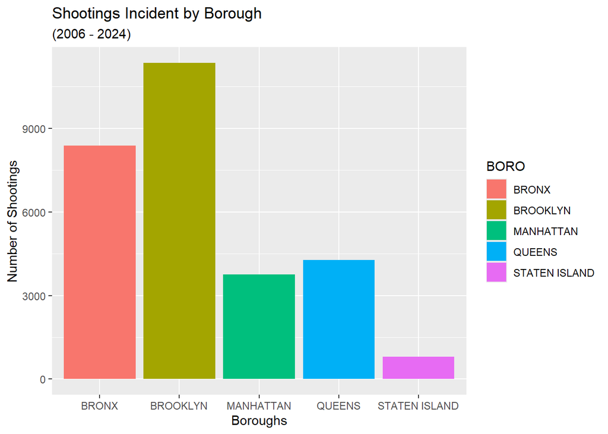

```r
cleanDataSet <- csvData %>%
  select(c("OCCUR_DATE","OCCUR_TIME","BORO","PRECINCT",
           "STATISTICAL_MURDER_FLAG","VIC_AGE_GROUP","VIC_SEX","VIC_RACE")) %>%
  mutate(OCCUR_DATE = mdy(OCCUR_DATE),
         OCCUR_TIME = hms(OCCUR_TIME),
         STATISTICAL_MURDER_FLAG = as.logical(STATISTICAL_MURDER_FLAG),
         Shootings = 1,
         Year = year(OCCUR_DATE))

cleanDataSet$VIC_AGE_GROUP[cleanDataSet$VIC_AGE_GROUP == "1022"] <- "UNKNOWN"

cleanDataSet %>%
  ggplot(aes(x = BORO, fill = BORO)) +
  geom_bar() +
  labs(title = "Shootings Incident by Borough",
       subtitle = "(2006 - 2024)",
       x = "Boroughs",
       y = "Number of Shootings",)
```

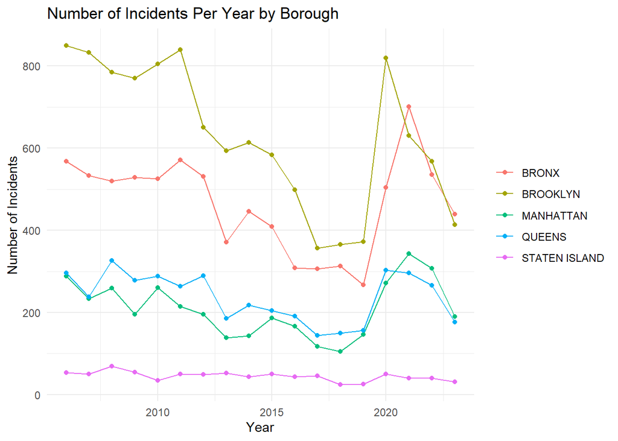

```r
cleanDataSet$Year <- year(cleanDataSet$OCCUR_DATE)

incident_counts <- cleanDataSet %>%
  group_by(BORO, Year) %>%
  summarise(incident_count = n(), .groups = "drop")

ggplot(incident_counts, aes(x = Year, y = incident_count, color = BORO, group = BORO)) +
  geom_line() +
  geom_point() +
  labs(title = "Number of Incidents Per Year by Borough",
       x = "Year",
       y = "Number of Incidents") +
  theme_minimal() +
  theme(legend.title = element_blank())
```

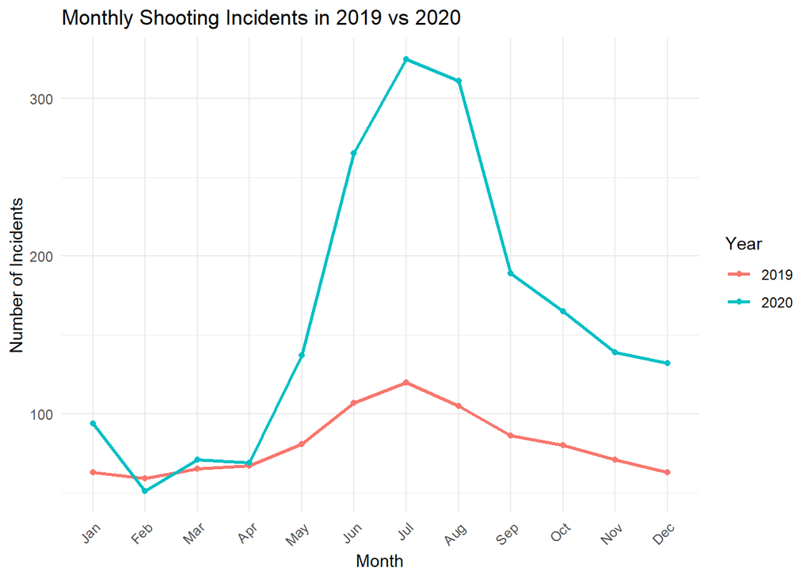

```r
cleanDataSet$OCCUR_DATE <- as.Date(cleanDataSet$OCCUR_DATE, format = "%Y-%m-%d")
cleanDataSet$Year <- year(cleanDataSet$OCCUR_DATE)
cleanDataSet$Month <- month(cleanDataSet$OCCUR_DATE, label = TRUE)


data_filtered <- cleanDataSet %>%
  filter(Year %in% c(2019, 2020))


data_monthly <- data_filtered %>%
  group_by(Year, Month) %>%
  summarise(Occurrences = n(), .groups = 'drop')


ggplot(data_monthly, aes(x = Month, y = Occurrences, color = factor(Year), group = Year)) +
  geom_line(linewidth = 1) +
  geom_point(linewidth = 2) +
  labs(title = "Monthly Shooting Incidents in 2019 vs 2020",
       x = "Month",
       y = "Number of Incidents",
       color = "Year") +
  theme_minimal() +
  theme(axis.text.x = element_text(angle = 45, hjust = 1))  # Rotate month labels for better readability
```

## Comparison of Victim Demographics

We can see from the graphics below that the most common victims in the reported incidents is by far Black men between the ages 18-44. This Demographic appears to be disproportionately affected by gun violence in New York City and this may suggest that there are broader issues of systemic inequalities that disproportionately impact the communities and neighborhoods these victims resided in, such as poverty, lack of access to education, and limited economic opportunities. This could also be indicative of racial disparities in both the incidence of violence and the broader social and economic factors that contribute to violent crime. These disparities might reflect longstanding issues such as structural racism, biased policing practices, or racial segregation in housing and employment.

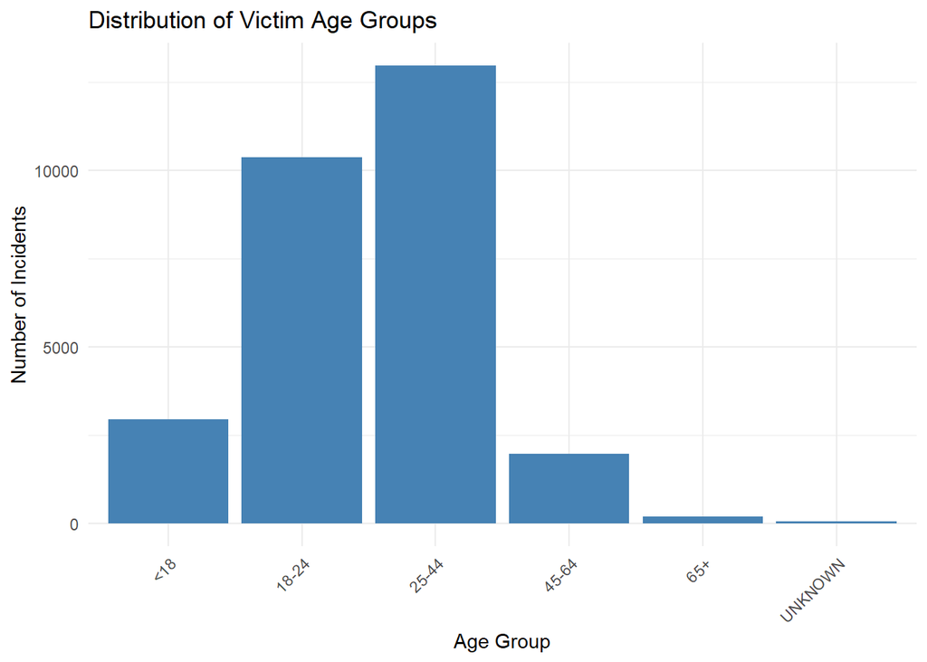

```r
ggplot(cleanDataSet, aes(x = VIC_AGE_GROUP)) +
  geom_bar(fill = "steelblue") +
  theme_minimal() +
  labs(title = "Distribution of Victim Age Groups",
       x = "Age Group",
       y = "Number of Incidents") +
  theme(axis.text.x = element_text(angle = 45, hjust = 1))
```

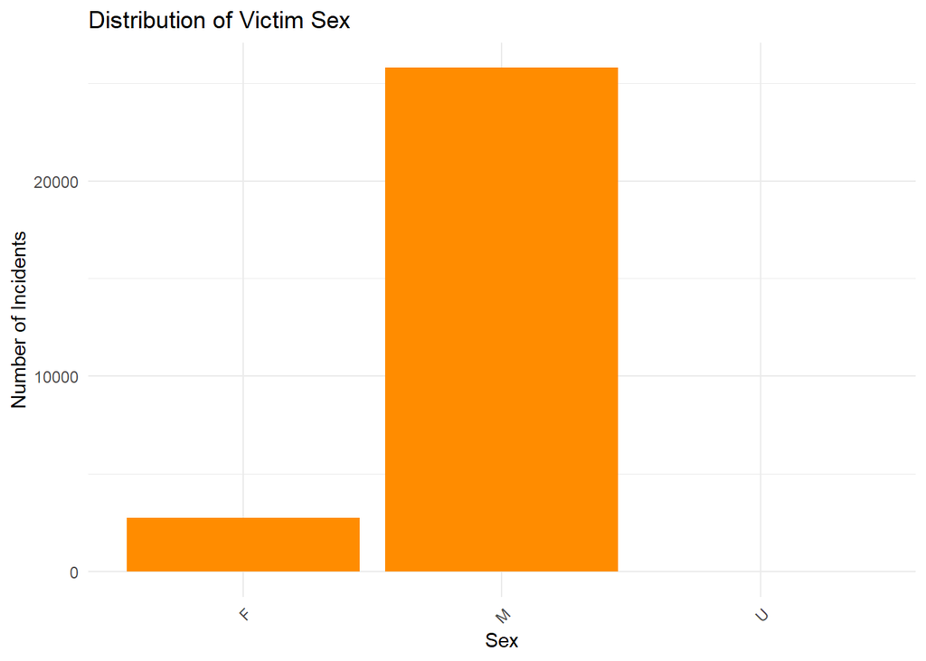

```r
ggplot(cleanDataSet, aes(x = VIC_SEX)) +
  geom_bar(fill = "darkorange") +
  theme_minimal() +
  labs(title = "Distribution of Victim Sex",
       x = "Sex",
       y = "Number of Incidents") +
  theme(axis.text.x = element_text(angle = 45, hjust = 1))
```

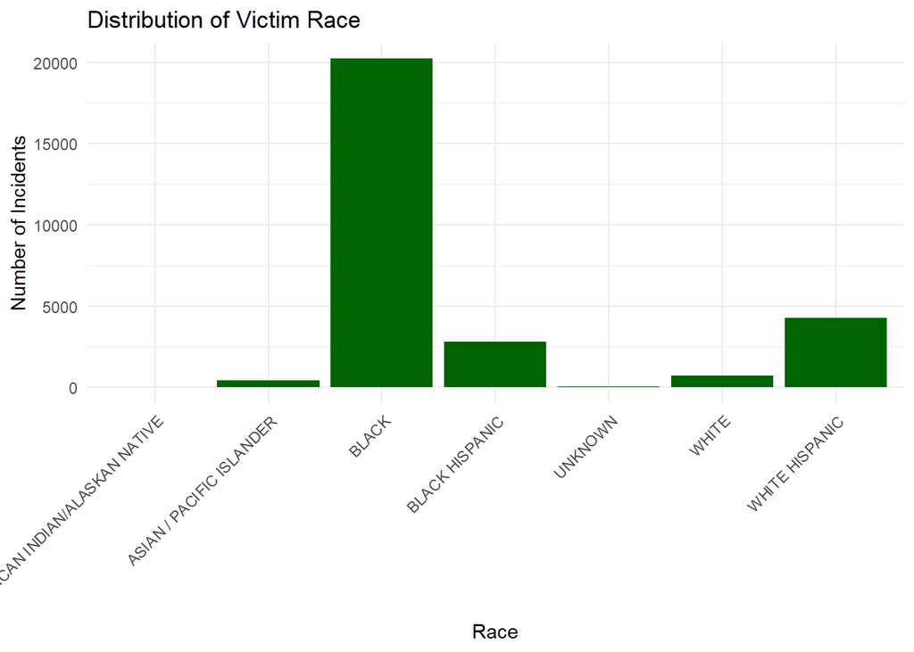

```r
ggplot(cleanDataSet, aes(x = VIC_RACE)) +
  geom_bar(fill = "darkgreen") +
  theme_minimal() +
  labs(title = "Distribution of Victim Race",
       x = "Race",
       y = "Number of Incidents") +
  theme(axis.text.x = element_text(angle = 45, hjust = 1))
```

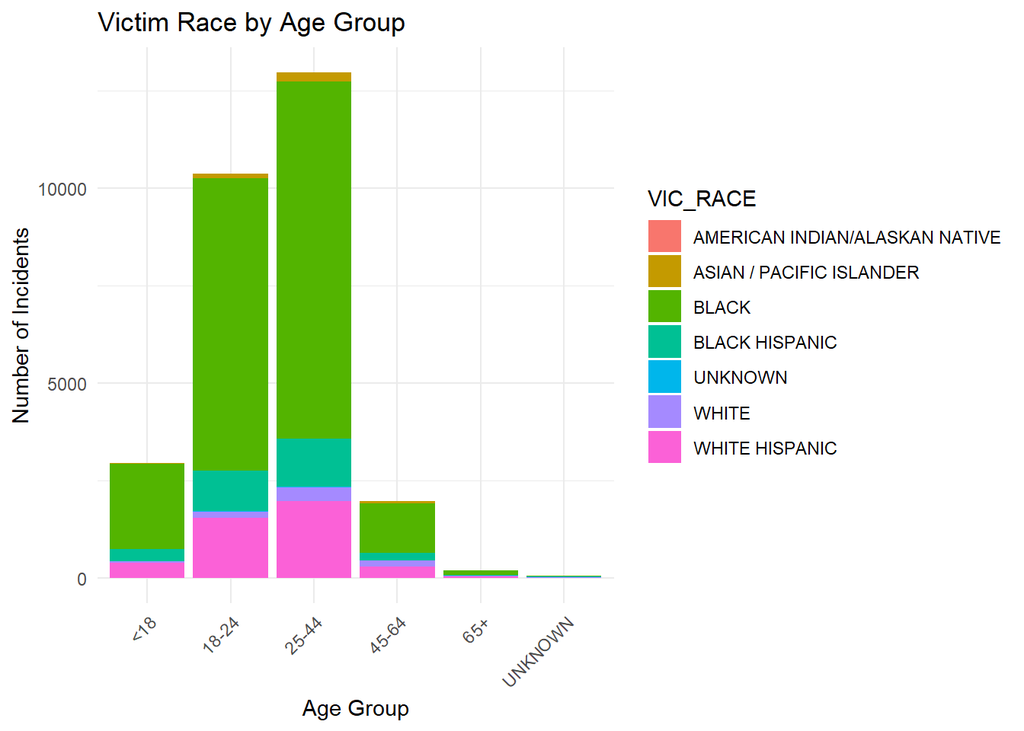

```r
ggplot(cleanDataSet, aes(x = VIC_AGE_GROUP, fill = VIC_RACE)) +
  geom_bar(position = "stack") +
  theme_minimal() +
  labs(title = "Victim Race by Age Group",
       x = "Age Group",
       y = "Number of Incidents") +
  theme(axis.text.x = element_text(angle = 45, hjust = 1))
```

We can see from the graph below that the incidents where this demographic were the victims of a shooting have fallen in line with all other shooting incidents in New York City over the last 2 years that we have data for. This drop off is promising however it is still worth noting that Black Men are still the most likely to be a victim of a shooting incident in New York.

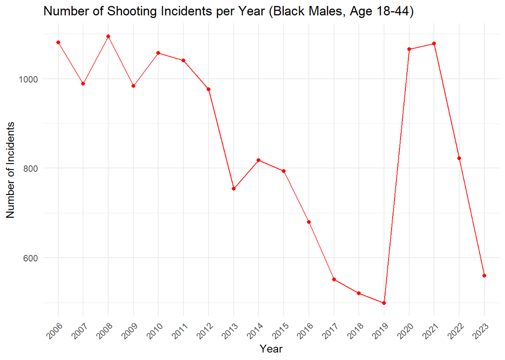

```r
cleanDataSet$OCCUR_DATE <- as.Date(cleanDataSet$OCCUR_DATE, format = "%Y-%m-%d")


cleanDataSet$Year <- format(cleanDataSet$OCCUR_DATE, "%Y")


filteredData <- cleanDataSet %>%
  filter(VIC_SEX == "M" & VIC_RACE == "BLACK" & VIC_AGE_GROUP %in% c("18-24", "25-44"))


incidents_by_year <- filteredData %>%
  group_by(Year) %>%
  summarise(Incidents = n())


ggplot(incidents_by_year, aes(x = Year, y = Incidents, group = 1)) +
  geom_line(color = "red") +
  geom_point(color = "red") +
  theme_minimal() +
  labs(title = "Number of Shooting Incidents per Year (Black Males, Age 18-44)",
       x = "Year",
       y = "Number of Incidents") +
  theme(axis.text.x = element_text(angle = 45, hjust = 1))
```